# 6. Starbucks App Customer Rewards Program (Identifying Ideal Customers)

### Oleksiy Anokhin | (August 16, 2020)

### Starbucks App Customer Rewards Program

### MSCA 31008 | Data Mining Principles | Professor U. Pamuksuz | Team Project

**Business problem:**

Identify the profile of the `ideal customer` (and the `worst customer`) in the dataset.

Starbucks managemnent wants to know who are our `best` and `worst` customers and the effect of offers on them.

The following problems are expected to solve:

- identfy the group of `best customers` and continiue to target them
- identify the group of `worst customers` (less active and less responsive to offers) and develop additional strategies for targeting them
- compare best customers' group in general and best customers in terms of offer response
- design an ideal offer

This work should be done in collaboration with PCA and clustering algorithms.

```python
# Import libraries
import pandas as pd
import numpy as np
import matplotlib.pyplot as plt
import seaborn as sns

# Set additional parameters
# Remove column display limits
pd.set_option('display.max_columns', None)
# pd.set_option('display.height', None)
pd.set_option('display.max_rows', None)
# pd.set_option('display.width', None)
plt.rcParams['figure.figsize'] = [15, 10]
sns.set_style("white")

# Create palette
starbucks_palette = ["#00704A", "#362415", "#eac784", "#604c4c"]
```

```python
# Read clean data
starbucks = pd.read_csv('starbucks.csv')

# Drop columns
starbucks = starbucks.drop(['Unnamed: 0'], axis = 1)

# Drop rows where offer_id = 0
# starbucks = starbucks[starbucks.offer_id != 0]
```

```python
#Select necessary variables
starbucks = starbucks[['customer_id', 'offer_id', 'amount', 'male', 'age', 'income', 'bogo', 'discount']]
```

```python
# Manipulate Starbucks dataframe
starbucks_grouped = starbucks.groupby('customer_id').agg({'amount':['sum'],
                                                          'male':['mean'],
                                                          'income':['mean'],
                                                          'bogo':['sum'],
                                                          'discount':['sum'],
                                                          'age':['mean']}).reset_index()

# Print
starbucks_grouped.head()
```

|  | customer_id | amount sum | male mean | income mean | bogo sum | discount sum | age mean |
| --- | --- | --- | --- | --- | --- | --- | --- |
| 0 | 0009655768c64bdeb2e877511632db8f | 127.60 | 1 | 72000.0 | 1.0 | 2.0 | 33 |
| 1 | 0020c2b971eb4e9188eac86d93036a77 | 214.10 | 0 | 90000.0 | 2.0 | 1.0 | 59 |
| 2 | 0020ccbbb6d84e358d3414a3ff76cffd | 154.05 | 0 | 60000.0 | 2.0 | 1.0 | 24 |
| 3 | 003d66b6608740288d6cc97a6903f4f0 | 48.34 | 0 | 73000.0 | 0.0 | 2.0 | 26 |
| 4 | 00426fe3ffde4c6b9cb9ad6d077a13ea | 68.51 | 0 | 65000.0 | 0.0 | 3.0 | 19 |

```python
# Drop the second layer of multi index
starbucks_grouped = starbucks_grouped.droplevel(1, axis = 1)
```

```python
# Drop 0 column
starbucks = starbucks_grouped.drop(starbucks_grouped.columns[[0]], axis = 1)
```

```python
# Print
starbucks.head(10)
```

|  | amount | male | income | bogo | discount | age |
| --- | --- | --- | --- | --- | --- | --- |
| 0 | 127.60 | 1 | 72000.0 | 1.0 | 2.0 | 33 |
| 1 | 214.10 | 0 | 90000.0 | 2.0 | 1.0 | 59 |
| 2 | 154.05 | 0 | 60000.0 | 2.0 | 1.0 | 24 |
| 3 | 48.34 | 0 | 73000.0 | 0.0 | 2.0 | 26 |
| 4 | 68.51 | 0 | 65000.0 | 0.0 | 3.0 | 19 |
| 5 | 138.36 | 0 | 74000.0 | 1.0 | 1.0 | 55 |
| 6 | 347.38 | 1 | 99000.0 | 2.0 | 1.0 | 54 |
| 7 | 20.36 | 1 | 47000.0 | 2.0 | 1.0 | 56 |
| 8 | 144.14 | 1 | 91000.0 | 1.0 | 2.0 | 54 |
| 9 | 375.12 | 0 | 119000.0 | 2.0 | 2.0 | 58 |

```python
# Create age groups
ages = ['20-', '20-29', '30-39', '40-49', '50-59', '60-69', '70+']
starbucks['age_group'] = pd.cut(starbucks.age, bins=[0, 20, 30, 40, 50, 60, 70, 120], right = False, labels = ages)
starbucks.head(30)
```

|  | amount | male | income | bogo | discount | age | age_group |
| --- | --- | --- | --- | --- | --- | --- | --- |
| 0 | 127.60 | 1 | 72000.0 | 1.0 | 2.0 | 33 | 30-39 |
| 1 | 214.10 | 0 | 90000.0 | 2.0 | 1.0 | 59 | 50-59 |
| 2 | 154.05 | 0 | 60000.0 | 2.0 | 1.0 | 24 | 20-29 |
| 3 | 48.34 | 0 | 73000.0 | 0.0 | 2.0 | 26 | 20-29 |
| 4 | 68.51 | 0 | 65000.0 | 0.0 | 3.0 | 19 | 20- |
| 5 | 138.36 | 0 | 74000.0 | 1.0 | 1.0 | 55 | 50-59 |
| 6 | 347.38 | 1 | 99000.0 | 2.0 | 1.0 | 54 | 50-59 |
| 7 | 20.36 | 1 | 47000.0 | 2.0 | 1.0 | 56 | 50-59 |
| 8 | 144.14 | 1 | 91000.0 | 1.0 | 2.0 | 54 | 50-59 |
| 9 | 375.12 | 0 | 119000.0 | 2.0 | 2.0 | 58 | 50-59 |
| 10 | 121.85 | 0 | 68000.0 | 1.0 | 0.0 | 28 | 20-29 |
| 11 | 62.93 | 1 | 61000.0 | 1.0 | 3.0 | 26 | 20-29 |
| 12 | 6.26 | 1 | 41000.0 | 4.0 | 1.0 | 71 | 70+ |
| 13 | 16.18 | 1 | 42000.0 | 3.0 | 1.0 | 24 | 20-29 |
| 14 | 279.16 | 0 | 81000.0 | 2.0 | 1.0 | 62 | 60-69 |
| 15 | 105.83 | 1 | 66000.0 | 1.0 | 3.0 | 61 | 60-69 |
| 16 | 166.40 | 0 | 54000.0 | 2.0 | 0.0 | 88 | 70+ |
| 17 | 248.88 | 1 | 83000.0 | 1.0 | 2.0 | 55 | 50-59 |
| 18 | 20.53 | 1 | 59000.0 | 2.0 | 1.0 | 21 | 20-29 |
| 19 | 133.25 | 1 | 102000.0 | 1.0 | 2.0 | 72 | 70+ |
| 20 | 163.92 | 1 | 80000.0 | 1.0 | 2.0 | 62 | 60-69 |
| 21 | 219.63 | 1 | 104000.0 | 2.0 | 1.0 | 50 | 50-59 |
| 22 | 53.55 | 0 | 76000.0 | 2.0 | 1.0 | 68 | 60-69 |
| 23 | 77.21 | 1 | 50000.0 | 1.0 | 2.0 | 94 | 70+ |
| 24 | 150.64 | 1 | 72000.0 | 1.0 | 3.0 | 44 | 40-49 |
| 25 | 63.50 | 1 | 77000.0 | 2.0 | 2.0 | 59 | 50-59 |
| 26 | 148.30 | 0 | 102000.0 | 1.0 | 2.0 | 58 | 50-59 |
| 27 | 6.98 | 1 | 42000.0 | 1.0 | 3.0 | 33 | 30-39 |
| 28 | 2.59 | 1 | 35000.0 | 2.0 | 3.0 | 28 | 20-29 |
| 29 | 241.55 | 1 | 86000.0 | 1.0 | 2.0 | 47 | 40-49 |

```python
# Create income groups
ages = ['40K-', '40-59K', '60-79K', '80-99K', '100K+']
starbucks['income_group'] = pd.cut(starbucks.income,
                                   bins=[0, 40000, 60000, 80000, 100000, 300000], right = False, labels = ages)
starbucks.head(20)
```

|  | amount | male | income | bogo | discount | age | age_group | income_group |
| --- | --- | --- | --- | --- | --- | --- | --- | --- |
| 0 | 127.60 | 1 | 72000.0 | 1.0 | 2.0 | 33 | 30-39 | 60-79K |
| 1 | 214.10 | 0 | 90000.0 | 2.0 | 1.0 | 59 | 50-59 | 80-99K |
| 2 | 154.05 | 0 | 60000.0 | 2.0 | 1.0 | 24 | 20-29 | 60-79K |
| 3 | 48.34 | 0 | 73000.0 | 0.0 | 2.0 | 26 | 20-29 | 60-79K |
| 4 | 68.51 | 0 | 65000.0 | 0.0 | 3.0 | 19 | 20- | 60-79K |
| 5 | 138.36 | 0 | 74000.0 | 1.0 | 1.0 | 55 | 50-59 | 60-79K |
| 6 | 347.38 | 1 | 99000.0 | 2.0 | 1.0 | 54 | 50-59 | 80-99K |
| 7 | 20.36 | 1 | 47000.0 | 2.0 | 1.0 | 56 | 50-59 | 40-59K |
| 8 | 144.14 | 1 | 91000.0 | 1.0 | 2.0 | 54 | 50-59 | 80-99K |
| 9 | 375.12 | 0 | 119000.0 | 2.0 | 2.0 | 58 | 50-59 | 100K+ |
| 10 | 121.85 | 0 | 68000.0 | 1.0 | 0.0 | 28 | 20-29 | 60-79K |
| 11 | 62.93 | 1 | 61000.0 | 1.0 | 3.0 | 26 | 20-29 | 60-79K |
| 12 | 6.26 | 1 | 41000.0 | 4.0 | 1.0 | 71 | 70+ | 40-59K |
| 13 | 16.18 | 1 | 42000.0 | 3.0 | 1.0 | 24 | 20-29 | 40-59K |
| 14 | 279.16 | 0 | 81000.0 | 2.0 | 1.0 | 62 | 60-69 | 80-99K |
| 15 | 105.83 | 1 | 66000.0 | 1.0 | 3.0 | 61 | 60-69 | 60-79K |
| 16 | 166.40 | 0 | 54000.0 | 2.0 | 0.0 | 88 | 70+ | 40-59K |
| 17 | 248.88 | 1 | 83000.0 | 1.0 | 2.0 | 55 | 50-59 | 80-99K |
| 18 | 20.53 | 1 | 59000.0 | 2.0 | 1.0 | 21 | 20-29 | 40-59K |
| 19 | 133.25 | 1 | 102000.0 | 1.0 | 2.0 | 72 | 70+ | 100K+ |

Now we need to visualize our information, splitting customers by gender.

```python
# Create dataframes for males and females
starbucks_m = starbucks[(starbucks.male == 1)]
starbucks_f = starbucks[(starbucks.male == 0)]
```

```python
# Check dimensions
print(starbucks_m.shape)
print(starbucks_f.shape)
```

```
(8484, 8)
(6129, 8)
```

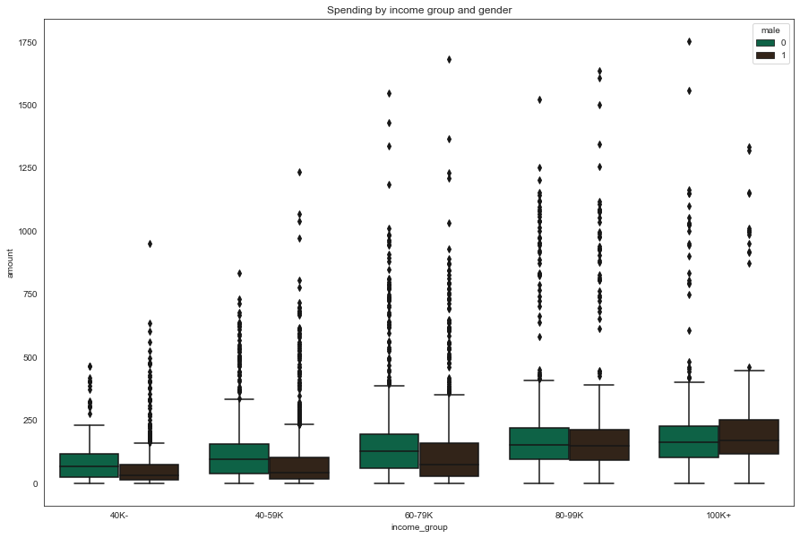

```python
# Compare both genders by income groups
# 1 = male, 0 = female
sns.boxplot(x = "income_group", y = "amount", hue = "male", data = starbucks, palette = starbucks_palette)
plt.title("Spending by income group and gender")
```

As we can see, more wealthy customers spend more money on Starbucks, which makes sense. Moreover, **women tend to spend more almost in all income groups** (besides 100K+, where males dominate).

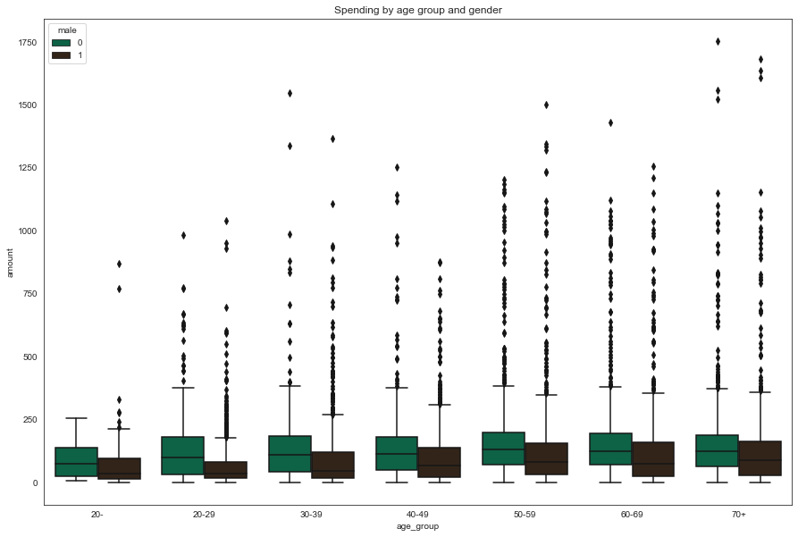

```python
# Compare both genders by age groups
# 1 = male, 0 = female
sns.boxplot(x = "age_group", y = "amount", hue = "male", data = starbucks, palette = starbucks_palette)
plt.title("Spending by age group and gender")
```

This chart is more interesting. As we can see, **women tend to spend significantly more money on Starbucks than men**. **They dominate in any age group**. Starbucks definitely should **improve its focus on men between 20 and 29 years old**. This vategory has the lowest results.

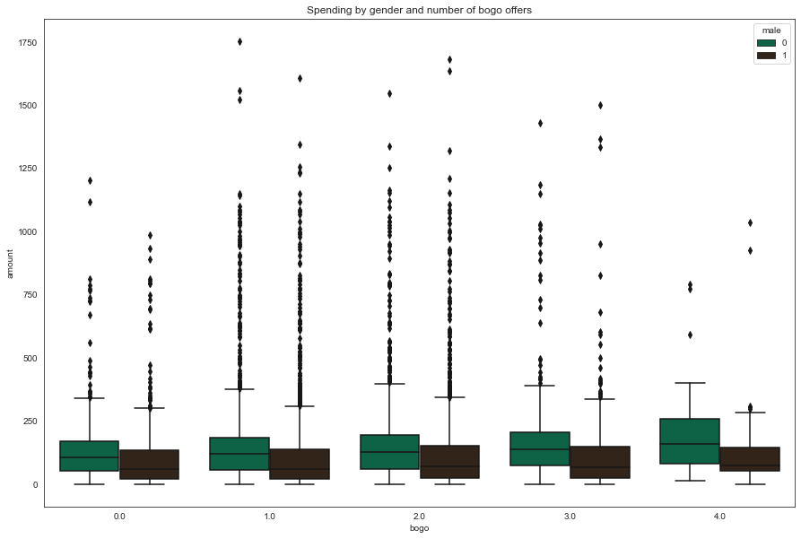

```python
# Find out who is most responsive to bogo offers by gender
# 1 = male, 0 = female
sns.boxplot(x = "bogo", y = "amount", hue = "male", data = starbucks, palette = starbucks_palette)
plt.title("Spending by gender and number of bogo offers")
```

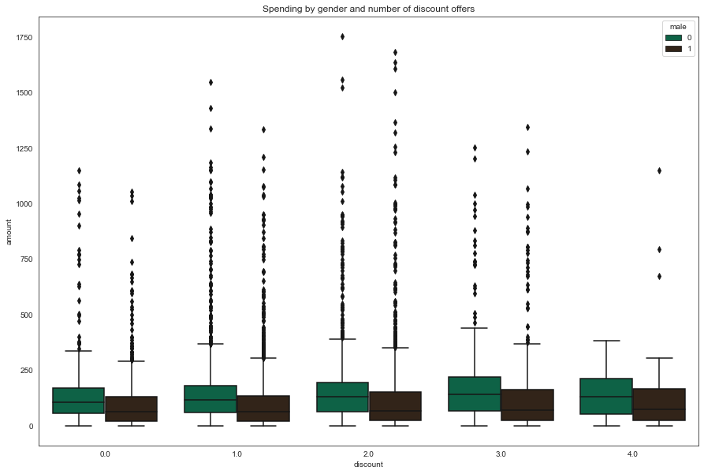

```python
# Find out who is most responsive to discount offer by gender
# 1 = male, 0 = female
sns.boxplot(x = "discount", y = "amount", hue = "male", data = starbucks, palette = starbucks_palette)
plt.title("Spending by gender and number of discount offers")
```

Another very interesting insght based on two charts above. How do customers respond to `bogo` and `discount` offers? Does their amount of spending increase based on number of both offer?

It is very interesting to see that **men and the amount they spend remain without any serious change despite all offers**. The average amount they spend is almost the same. However, the amount women spend increases with the number of offers especially for `bogo`.

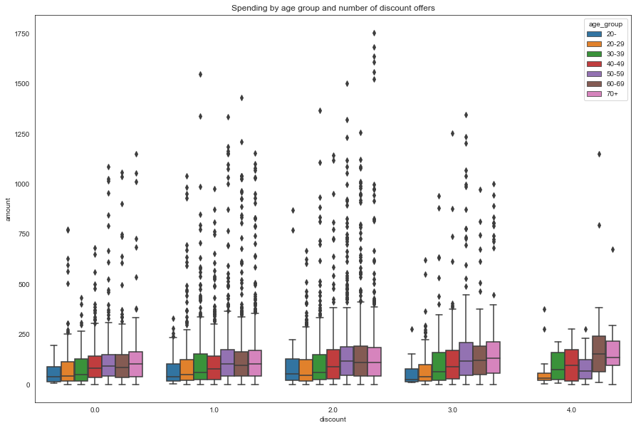

```python
# Find out who is most responsive to discount offer by age group
# 1 = male, 0 = female
sns.boxplot(x = "discount", y = "amount", hue = "age_group", data = starbucks)
plt.title("Spending by age group and number of discount offers")
```

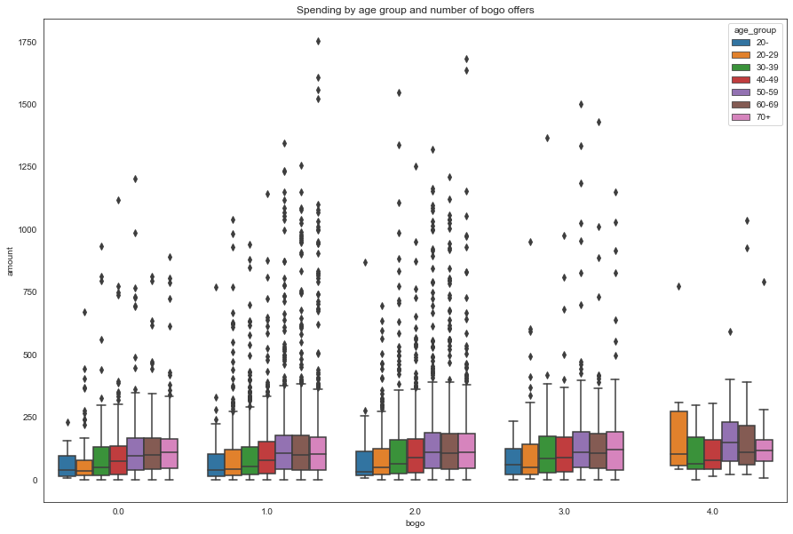

```python
# Find out who is most responsive to bogo offer by age group
# 1 = male, 0 = female
sns.boxplot(x = "bogo", y = "amount", hue = "age_group", data = starbucks)
plt.title("Spending by age group and number of bogo offers")
```

This is also very interesting. We can see that **customers between 20 and 29 years old decrease their spending amount with the increase of the number of discount offers**. This is pretty contrintuitive. **This age group shold not be targeted too frequently.**

At the same time, **the same age group has a significant response rate to bogo offers. The more they receive - the more they spend.**

Hence, we identified **a group of customers, which reacts very differently on various types of offers**. We definitely need to tune parameters of the program for this group.

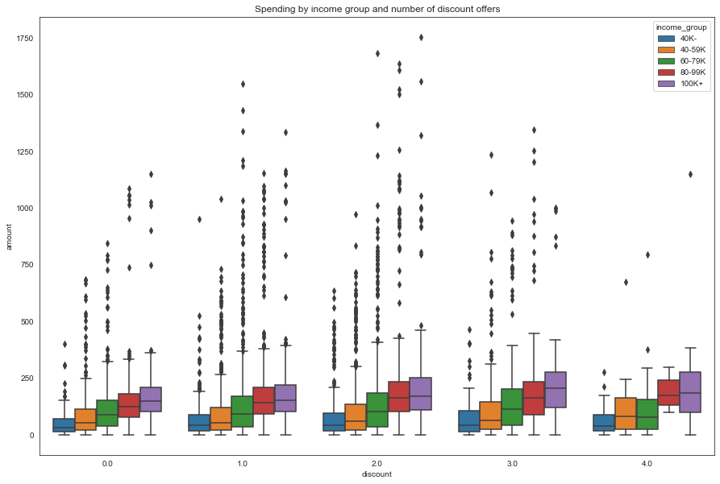

```python
# Find out who is most responsive to discount offer by income group
# 1 = male, 0 = female
sns.boxplot(x = "discount", y = "amount", hue = "income_group", data = starbucks)
plt.title("Spending by income group and number of discount offers")
```

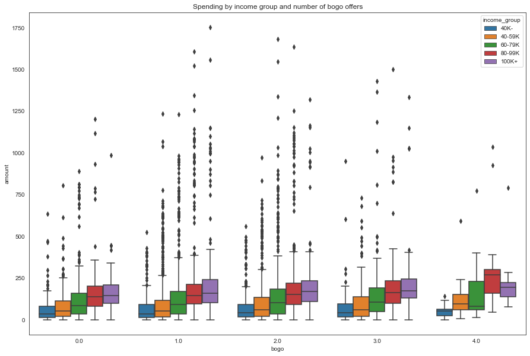

```python
# Find out who is most responsive to bogo offer by income group
# 1 = male, 0 = female
sns.boxplot(x = "bogo", y = "amount", hue = "income_group", data = starbucks)
plt.title("Spending by income group and number of bogo offers")
```

Results of two plots above are not that surprising. **The wealthier our customers, the more responsive they are to our offers** and its growing number.

[figure not shown]

```python
# Find out who is most responsive by age and income group
sns.boxplot(x = "age_group", y = "amount", hue = "income_group", data = starbucks)
plt.title("Spending by income and age groups")
```

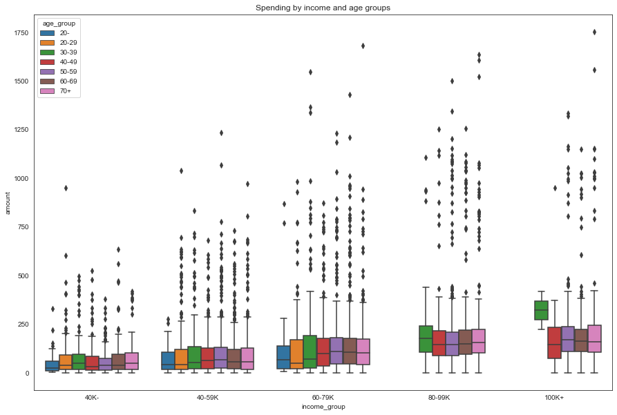

```python
# Find out who is most responsive by age and income group
sns.boxplot(x = "income_group", y = "amount", hue = "age_group", data = starbucks)
plt.title("Spending by income and age groups")
```

This is also interesting. WE plotted in different formats the amount spent by age and income groups. Rich people (100K+ income) look an outlier here, but we also can see, that people with 80-99K income between 30 and 39 years old is out big target audience.

```python
# Create dataframes for males and females
starbucks.head()
```

|  | amount | male | income | bogo | discount | age | age_group | income_group |
| --- | --- | --- | --- | --- | --- | --- | --- | --- |
| 0 | 127.60 | 1 | 72000.0 | 1.0 | 2.0 | 33 | 30-39 | 60-79K |
| 1 | 214.10 | 0 | 90000.0 | 2.0 | 1.0 | 59 | 50-59 | 80-99K |
| 2 | 154.05 | 0 | 60000.0 | 2.0 | 1.0 | 24 | 20-29 | 60-79K |
| 3 | 48.34 | 0 | 73000.0 | 0.0 | 2.0 | 26 | 20-29 | 60-79K |
| 4 | 68.51 | 0 | 65000.0 | 0.0 | 3.0 | 19 | 20- | 60-79K |

We can go even further and **split our customers into two dataframes by gender**, running the same analysis.

**Males' spending by income and age groups as well as offer category and number of offers**

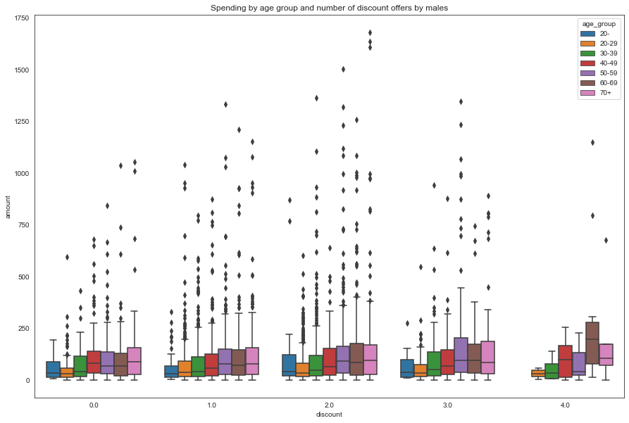

```python
# Find out who is most responsive to discount offer by age group (males)
sns.boxplot(x = "discount", y = "amount", hue = "age_group", data = starbucks_m)
plt.title("Spending by age group and number of discount offers by males")
```

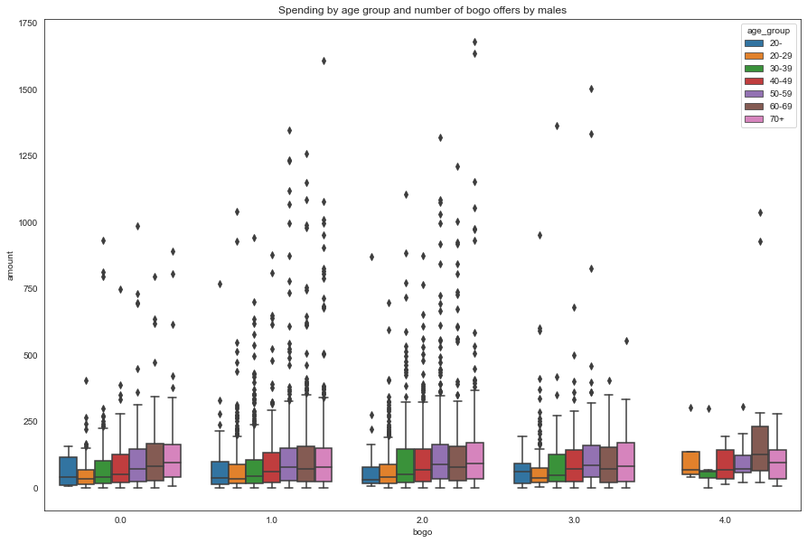

```python
# Find out who is most responsive to bogo offer by age group (males)
sns.boxplot(x = "bogo", y = "amount", hue = "age_group", data = starbucks_m)
plt.title("Spending by age group and number of bogo offers by males")
```

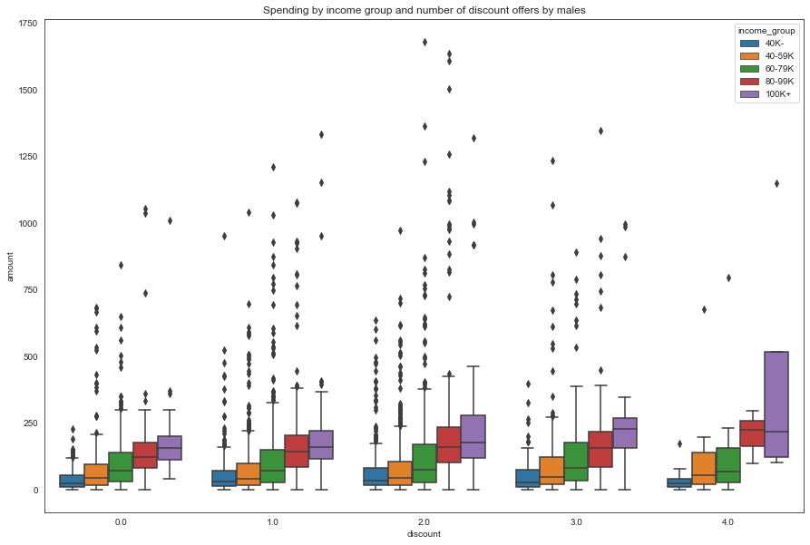

```python
# Find out who is most responsive to discount offer by age group (males)
sns.boxplot(x = "discount", y = "amount", hue = "income_group", data = starbucks_m)
plt.title("Spending by income group and number of discount offers by males")
```

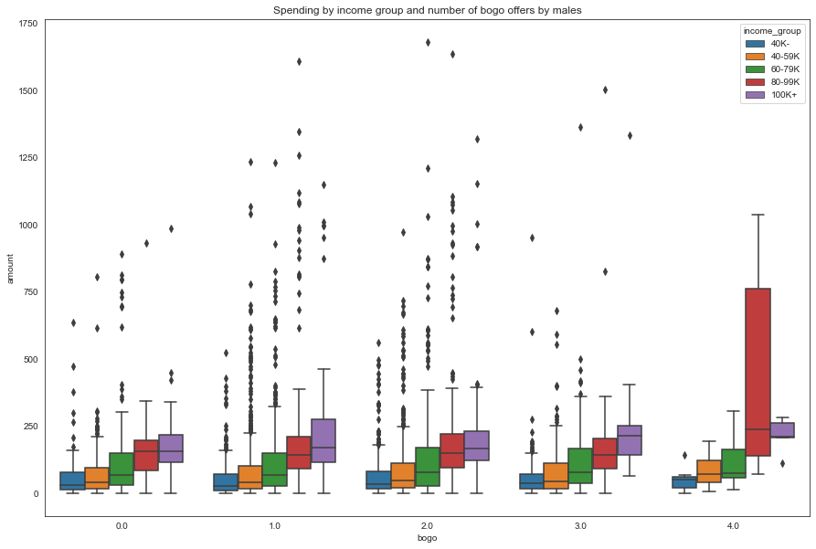

```python
# Find out who is most responsive to bogo offer by age group (males)
sns.boxplot(x = "bogo", y = "amount", hue = "income_group", data = starbucks_m)
plt.title("Spending by income group and number of bogo offers by males")
```

**Females' spending by income and age groups as well as offer category and number of offers**

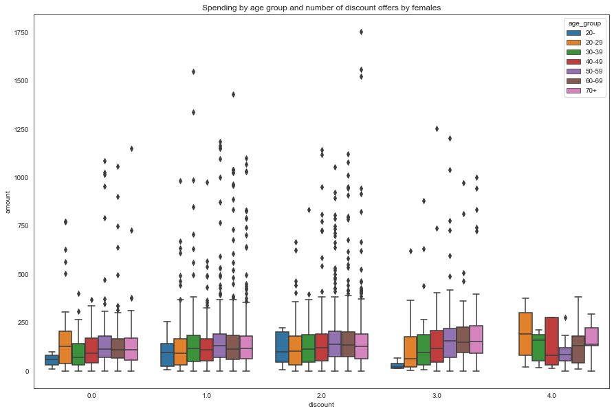

```python
# Find out who is most responsive to discount offer by age group (females)
sns.boxplot(x = "discount", y = "amount", hue = "age_group", data = starbucks_f)
plt.title("Spending by age group and number of discount offers by females")
```

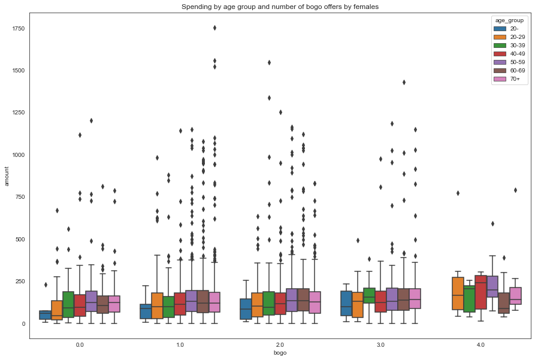

```python
# Find out who is most responsive to bogo offer by age group (females)
sns.boxplot(x = "bogo", y = "amount", hue = "age_group", data = starbucks_f)
plt.title("Spending by age group and number of bogo offers by females")
```

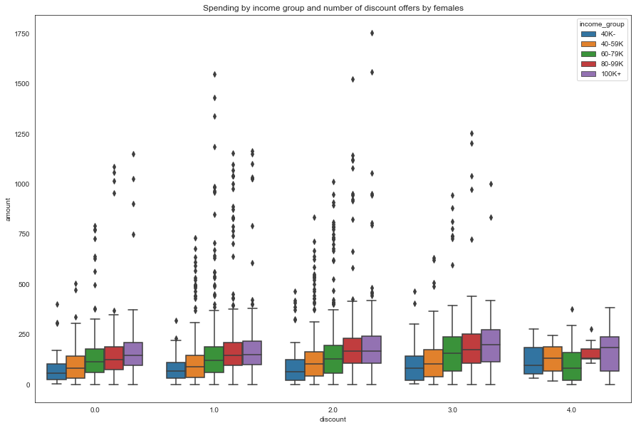

```python
# Find out who is most responsive to discount offer by income group (females)
sns.boxplot(x = "discount", y = "amount", hue = "income_group", data = starbucks_f)
plt.title("Spending by income group and number of discount offers by females")
```

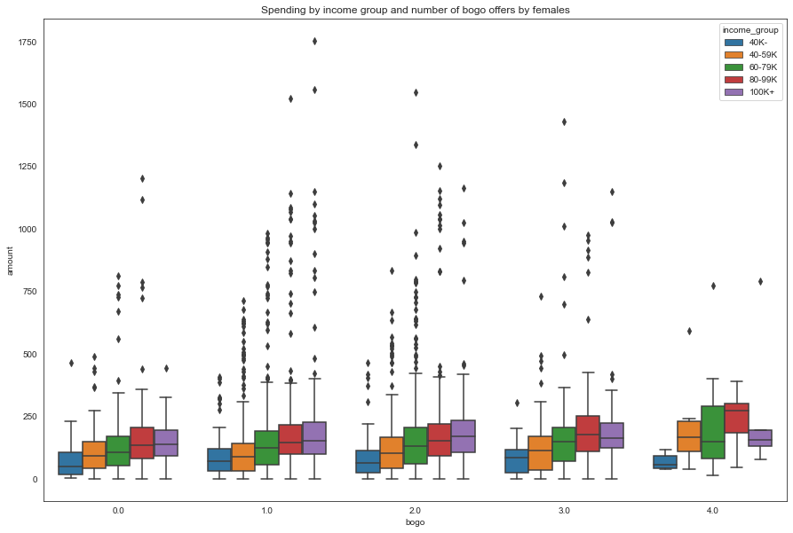

```python
# Find out who is most responsive to bogo offer by income group (females)
sns.boxplot(x = "bogo", y = "amount", hue = "income_group", data = starbucks_f)
plt.title("Spending by income group and number of bogo offers by females")
```

**Consculsion:** we completed a pretty comprehensive analysis of spending by Starbucks customers, combining them simultanious by different parameters - age and income group, type and number of offers, and gender.

As a result, now we can clearly identify several categories of our **best** and **"worst"** groups of customers. In turn, it will allow Starbucks to continue its current strategies for responsive customers and review own marketing strategies for customers, who are not that active.